# Statistica I

Esercitazione 3: variabilità, istogrammi, boxplot, simmetria, curtosi

Autore/Autrice

Affiliazione

Tommaso Rigon

DEMS

Alcuni dei problemi di questa esercitazione **non** sono stati svolti a lezione. Si consiglia agli studenti di provare a risolvere i problemi autonomamente.

## Strani indici

Si dica se gli indici elencati di seguito possono o non possono essere interpretati come una misura di posizione oppure di variabilità di un certo insieme di dati tutti positivi, $y_1, \dots, y_n$. Il simbolo $\mathcal{Q}_p$ indica il quantile $p$.

1. $$\frac{1}{n^2}\sum_{i=1}^n\sum_{j=1}^n(y_i - y_j).$$
2. $$\frac{1}{n^2}\sum_{i=1}^n\sum_{j=1}^n(y_i - y_j)^2.$$
3. $$\frac{1}{2n^2}\sum_{i=1}^n\sum_{j=1}^n|y_i - y_j|.$$
4. $$\exp\left\{\frac{1}{n}\sum_{i=1}^n\log{x_i}\right\}.$$
5. $$\mathcal{Q}_{0.5} - \mathcal{Q}_{0.25} + |\mathcal{Q}_{0.5} - \mathcal{Q}_{0.75}|$$

### Schema della soluzione

1. Questo indice è sempre pari a zero, quindi certamente non è adatto per misurare nè la posizione nè la variabilità.
2. Questo indice è pari al doppio della varianza campionaria.
3. Questo indice è una misura robusta di variabilità.
4. Questo indice è una riscrittura della media geometrica $\mathbb{G}$.
5. Questo indice è una riscrittura dello scarto interquartile. Si noti infatti che $|\mathcal{Q}_{0.5} - \mathcal{Q}_{0.75}| = \mathcal{Q}_{0.75} - \mathcal{Q}_{0.5}$.

## Tubi catodici

Una vecchia fabbrica di televisori produce due tipi di tubi catodici: il tipo A e il tipo B. I tubi catodici hanno tempi di durata media, rispettivamente di $1495$ ore e $1875$ ore e scarti quadratici medi rispettivamente di $280$ ore e $310$ ore. In generale, è preferibile il tubo catodico che ha la durata più alta e variabilità più bassa.

Quale dei due tubi catodici è preferibile?

### Schema della soluzione

I tubi catodici di tipo B hanno durata media maggiore dei tubi catodici di tipo A. Anche la varianza dei tubi catodici di tipo B è maggiore di quelli di tipo A.

Tuttavia i due scarti quadratici medi non sono immediatamente confrontabili, poichè le medie delle due tipologie sono diverse. Un indicatore più adeguato in questo caso è il coefficiente di variazione:

$$\text{CV}_A = \frac{\sigma_A}{\bar{x}_A} = \frac{280}{1495} \approx 0.187, \quad \text{CV}_B = \frac{\sigma_B}{\bar{x}_B} = \frac{310}{1875} \approx 0.165,$$

Concludiamo quindi che la tipologia B è preferibile, essendo caratterizzata da una media maggiore e un coefficiente di variazione minore.

## Lampadine

Un’azienda produttrice di lampadine controlla la durata dei suoi prodotti facendo funzionare $n = 200$ lampadine ininterrottamente fino a che si rompono. A determinati istanti di tempo si effettua un controllo e si verifica quante in totale non sono più funzionanti. I dati sono riportati nella tabella seguente

| Tempo | 10 | 30 | 100 | 150 | 200 | 400 |
| --- | --- | --- | --- | --- | --- | --- |
| Rotture cumulate | 2 | 20 | 40 | 80 | 120 | 170 |

Si noti che $30$ lampadine non si sono mai rotte.

1. Si valuti la “durata media” e si dia un indice di posizione appropriato per sintetizzare la distribuzione delle durate.
2. Si calcoli un opportuno indice di variabilità.

### Schema della soluzione

In primo luogo, ri-organizziamo la tabella in maniera tale da evidenziare gli intervalli considerati

| Tempo | $(0, 10]$ | $(10, 30]$ | $(30, 100]$ | $(100,150]$ | $(150,200]$ | $(200,400]$ | $(400, \infty]$ |
| --- | --- | --- | --- | --- | --- | --- | --- |
| $n_j$ | 2 | 18 | 20 | 40 | 40 | 50 | 30 |
| $f_j$ | 0.01 | 0.09 | 0.10 | 0.20 | 0.20 | 0.25 | 0.15 |
| $F_j$ | 0.01 | 0.1 | 0.20 | 0.40 | 0.60 | 0.85 | 1 |

Si noti che un totale di $200 - 170 = 30$ lampadine non si sono mai rotte entro il tempo $400$. Questo pone delle difficoltà nel calcolo della media. Infatti, non è chiaro quale valore sia il valore centrale dell’intervallo $(400, \infty]$. Qualunque scelta dovrebbe ben essere giustificata.

La mediana non risente di questo problema. La mediana appartiene necessariamente all’intervallo $(150,200]$. Utilizzando l’approssimazione lineare, otteniamo che

$$\text{Me} \approx 150 + (200 - 150)\frac{0.5 - 0.4}{0.6 - 0.4} = 175.$$
Per le stesse ragioni menzionate prima, ci sono delle difficoltà nel calcolo della varianza. Consideriamo quindi lo scarto interquartile. Utilizzando l’approssimazione lineare, si ottiene

$$\mathcal{Q}_{0.25} \approx 100 + (150 - 100)\frac{0.25 - 0.2}{0.4 - 0.2} = 112.5.$$
$$\mathcal{Q}_{0.75} \approx 200 + (400 - 200)\frac{0.75 - 0.6}{0.85 - 0.6} = 320.$$
Pertanto lo scarto interquartile è pari a

$$\mathcal{Q}_{0.75} - \mathcal{Q}_{0.25} = 207.5.$$

## Altezza delle persone

Rilevando in centrimetri la statura di $n = 136$ persone, si sono contate $30$ persone con statura compresa tra i $150$ e $170$cm; $44$ con statura tra $170$ e $180$; $52$ tra $180$ e $190$ e $10$ tra $190$ e $197$, che è la statura massima rilevata.

Si rappresentino i dati con un istogramma.

### Schema della soluzione

Supponendo che le classi siano chiuse a destra, possiamo rappresentare i dati nella seguente tabella:

| Classi di statura | Frequenza assoluta | Ampiezza della classe | Densità di frequenza | Altezza rettangoli |
| --- | --- | --- | --- | --- |
| $(150, 170]$ | 30 | 20 | 1.5 | 0.011 |
| $(170, 180]$ | 44 | 10 | 4.4 | 0.032 |
| $(180,190]$ | 52 | 10 | 5.2 | 0.038 |
| $(190,197]$ | 10 | 7 | 1.429 | 0.010 |

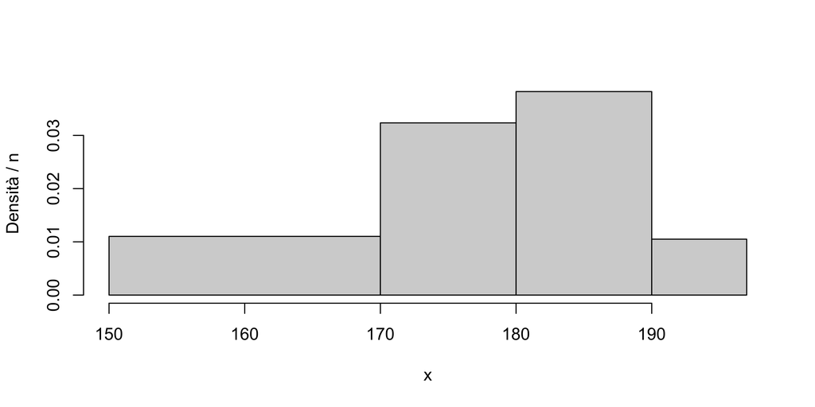

## Moscerini della frutta

Un gruppo di ricercatori sta valutando la tossicità su *D. melanogaster* (moscerini della frutta) di un composto molecolare. I moscerini vengono divisi casualmente in 10 gruppi e vengono trattati col composto. Dopo 1 giorno si registra la percentuale di moscerini non sopravvissuti per l’eccessiva tossicità.

| Gruppo | 1 | 2 | 3 | 4 | 5 | 6 | 7 | 8 | 9 | 10 |
| --- | --- | --- | --- | --- | --- | --- | --- | --- | --- | --- |
| Frazione di decessi | 0.38 | 0.32 | 0.59 | 0.58 | 0.41 | 0.87 | 0.54 | 0.4 | 0.42 | 0.4 |

1. Si individuino le distribuzioni di frequenze assolute cumulate, relative e relative cumulate della mortalità dei moscerini.
2. Si tracci il box-plot.
3. Si calcolino media e lo scarto quadratico medio.
4. Si calcoli un indice di variabilità robusto.

### Schema della soluzione

La tabella delle frequenze è riportata qui di seguito.

| Frazione di decessi | 0.32 | 0.38 | 0.4 | 0.41 | 0.42 | 0.54 | 0.58 | 0.59 | 0.87 |  |
| --- | --- | --- | --- | --- | --- | --- | --- | --- | --- | --- |
| $n_j$ | 1 | 1 | 2 | 1 | 1 | 1 | 1 | 1 | 1 |  |
| $N_j$ | 1 | 2 | 4 | 5 | 6 | 7 | 8 | 9 | 10 |  |
| $f_j$ | 0.1 | 0.1 | 0.2 | 0.1 | 0.1 | 0.1 | 0.1 | 0.1 | 0.1 |  |
| $F_j$ | 0.1 | 0.2 | 0.4 | 0.5 | 0.6 | 0.7 | 0.8 | 0.9 | 1 |  |

La media è pari a 0.491 mentre lo scarto quadratico medio è pari a 0.153. La mediana è pari a 0.415, mentre i quantili sono invece pari a

```
##  25%  75%
## 0.40 0.58
```

È presente un outlier. Pertanto, il boxplot si ottiene come segue:

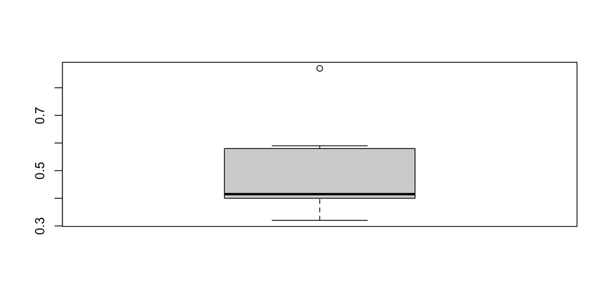

Un indice di variabilità robusto è il MAD, pari in questo caso a 0.065.